# Compensatory Renal Hypertrophy : RNA-seq Analysis

Vincent Wong

13 July, 2021

# Setup

First we load all the required `R` packages

```r
library(tidyverse)
library(magrittr)
library(cowplot)
library(edgeR)
library(RUVSeq)
library(AnnotationHub)
library(ensembldb)
library(scales)
library(org.Mm.eg.db)
library(pander)
library(ggrepel)
library(pheatmap)
library(RColorBrewer)
library(fgsea)
library(msigdbr)
library(AnnotationDbi)
library(enrichplot)
library(clusterProfiler)
library(kableExtra)
```

```r
panderOptions("table.split.table", Inf)
panderOptions("table.style", "rmarkdown")
panderOptions("big.mark", ",")
```

## Annotations

```r
ah <- AnnotationHub() %>%
    subset(species == "Mus musculus") %>%
    subset(dataprovider == "Ensembl") %>%
    subset(genome == "GRCm39") %>% # GRCm39 is relative new release 104 is not out yet
    subset(rdataclass == "EnsDb")
ensDb <- ah[["AH89457"]]
```

```r
grTrans <- transcripts(ensDb)
trLengths <- exonsBy(ensDb, "tx") %>%
  width() %>%
  vapply(sum, integer(1))
mcols(grTrans)$length <- trLengths[names(grTrans)]
```

Similarly to the Quality Assessment steps, `GRanges` objects were formed at the gene and transcript levels, to enable estimation of GC content and length for each transcript and gene. GC content and transcript length are available for each transcript, and for gene-level estimates, GC content was taken as the sum of all GC bases divided by the sum of all transcript lengths, effectively averaging across all transcripts. Gene length was defined as the median transcript length.

```r
gcGene <- grTrans %>%
  mcols() %>%
  as.data.frame() %>%
  dplyr::select(gene_id, tx_id, gc_content, length, tx_name) %>%
  as_tibble() %>%
  group_by(gene_id) %>%
  summarise(
    gc_content = sum(gc_content*length) / sum(length),
    length = ceiling(median(length)),)

grGenes <- genes(ensDb)
mcols(grGenes) %<>%
  as.data.frame() %>%
  left_join(gcGene) %>%
  as.data.frame() %>%
  DataFrame()
```

Sample metadata was also loaded

```r
setwd("C:/Users/cronos/Box Sync/Desktop/Renal Hypertrophy/CRH_RNAseq")

samples <- read_csv("samples.csv") %>%
  distinct(sampleName, .keep_all = TRUE) %>%
  dplyr::select(sample = sampleName,time= timepoint, everything()) %>%
  mutate(
    treatment = factor(treatment, levels = c("Sham", "Unx")),
    time = factor(time, levels=c("24hr","48hr","72hr")),
    group = factor(group,
                       levels=c("Sham.24hr", "Sham.48hr", "Sham.72hr",
                                "Unx.24hr", "Unx.48hr", "Unx.72hr")))

groupCols <- samples$group %>%
  levels() %>%
  length() %>%
  brewer.pal("Dark2") %>%
  setNames(levels(samples$group))

timeCols <- samples$time %>%
  levels() %>%
  length() %>%
  brewer.pal("Set2") %>%
  setNames(levels(samples$time))

treatCols <- samples$treatment %>%
  levels() %>%
  length() %>%
  brewer.pal("Set1") %>%
  setNames(levels(samples$treatment)) %>%
  .[-3]

samples %>%
  kable %>%
  kable_styling() %>%
  scroll_box(height="500px")
```

[output not shown]

## Load Data

Load the topTables and dgeList from DE analysis

```r
topTables <- readRDS("C:/Users/cronos/Box Sync/Desktop/Renal Hypertrophy/CRH_RNAseq/topTables.rds")
dgeList <- readRDS("C:/Users/cronos/Box Sync/Desktop/Renal Hypertrophy/CRH_RNAseq/dgeCRH_RNA.rds")
```

### Additional Functions

```r
# contLabeller <- as_labeller(
#   c(KOVsWT = "-/- Vs +/+",
#     KO = "-/-",
#     WT = "+/+"))

contLabeller <- as_labeller(
  c(KO = "Sham Vs Unx"))

geneLabeller <- structure(dgeList$genes$gene_name, names = dgeList$genes$gene_id) %>%
  as_labeller()
```

Labeller functions for genotypes, contrasts and gene names were additionally defined for simpler plotting using `ggplot2`.

## Find Variable Genes

```r
geneID24.48<-topTables$Sham24vsSham48 %>%
  dplyr::filter(DE == TRUE & adj.P.Val <0.01) %>%
  .$gene_id

geneID24.72<-topTables$Sham24vsSham72 %>%
  dplyr::filter(DE == TRUE & adj.P.Val <0.01) %>%
  .$gene_id

geneID48.72<-topTables$Sham48vsSham72 %>%
  dplyr::filter(DE == TRUE & adj.P.Val <0.01) %>%
  .$gene_id

geneID_variable  <- c(geneID24.48,geneID24.72) %>% unique()
```

## Group all DE genes between “Sham24vsUnx24” & “Sham48vsUnx48” & “Sham72vsUnx72”

```r
DE24<-topTables$Sham24vsUnx24 %>%
  dplyr::filter(DE == TRUE) %>%
  .$gene_id

DE48<-topTables$Sham48vsUnx48 %>%
  dplyr::filter(DE == TRUE) %>%
  .$gene_id

DE72<-topTables$Sham72vsUnx72 %>%
  dplyr::filter(DE == TRUE) %>%
  .$gene_id

stable_in_sham <- c(DE24,DE48,DE72) %>% unique() %>%
  setdiff(.,geneID_variable)
```

## Mark genes that are stable

```r
#Mark stable sham genes in topTable
topTables_stable <- topTables[1:3] %>%
  sapply(function(x){
    x %>% as.data.frame() %>%
      mutate(Stable = case_when(gene_id %in% stable_in_sham & DE == TRUE ~ TRUE),
      Stable = ifelse(is.na(Stable), "FALSE", Stable))}, simplify = FALSE)
```

## Top 20 from each group for boxplot

```r
# select some genes for plotting
out1 <- topTables_stable$Sham24vsUnx24 %>% dplyr::filter(DE==TRUE, Stable==TRUE) %>% dplyr::slice(1:20)
out2 <- topTables_stable$Sham48vsUnx48 %>% dplyr::filter(DE==TRUE, Stable==TRUE) %>% dplyr::slice(1:20)
out3 <- topTables_stable$Sham72vsUnx72 %>% dplyr::filter(DE==TRUE, Stable==TRUE) %>% dplyr::slice(1:20)

combined<-rbind(out1,out2,out3) %>% .$gene_id %>% unique()
```

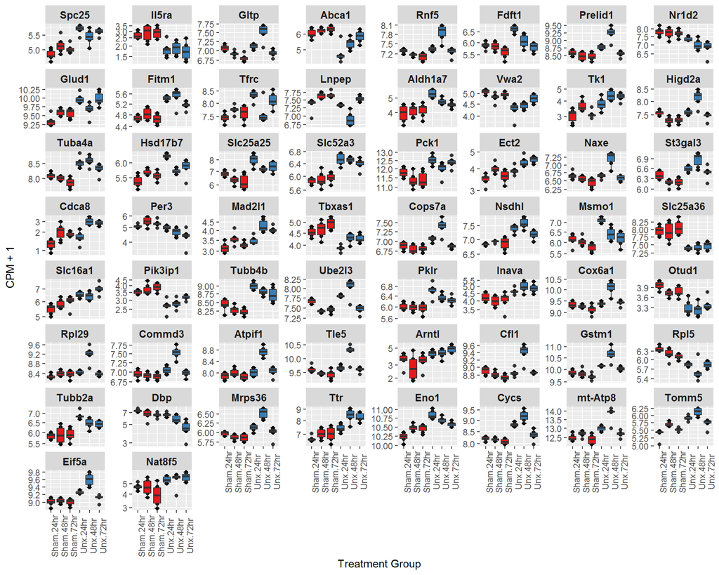

```r
cpm(dgeList, log=TRUE, prior.count = 3)[combined,] %>%
  head(.,n=100) %>%
  as.data.frame() %>%
  rownames_to_column("gene_id") %>%
    as_tibble() %>%
    gather(key = "sample", value = "CPM", -gene_id) %>%
    mutate(CPM = CPM + 1) %>%
    left_join(dgeList$samples) %>%
  mutate(treatment = fct_relevel(treatment, "Sham","Unx")) %>%
  mutate(group = fct_relevel(group, "Sham.24hr","Sham.48hr","Sham.72hr","Unx.24hr","Unx.48hr","Unx.72hr")) %>%
    ggplot(aes(group, CPM, fill = treatment)) +
  geom_point() +
    # geom_text_repel(aes(label = time)) +
  stat_boxplot(geom='errorbar', linetype=1, width=0.5)+
    geom_boxplot() +
    facet_wrap(
        ~gene_id,
        scales = "free_y",
        labeller = as_labeller(
            structure(dgeList$genes$gene_name, names = dgeList$genes$gene_id)
        )) + scale_fill_manual(values = treatCols) +
    scale_y_log10()  +
    labs(x = "Treatment Group",
         y = "CPM + 1") +
    theme(legend.position = "none",axis.text.x = element_text(angle = 90),
          strip.text = element_text(size= 10, face="bold"))
```

## Look for transcription factors

```r
Mus_musculus_TF <- read.delim("C:/Users/cronos/Box Sync/Desktop/Renal Hypertrophy/CRH_RNAseq/Mus_musculus_TF.txt")
```

```r
mmTF <- Mus_musculus_TF$Symbol
```

TF for DE 24

```r
DE24_symbol <- topTables_stable$Sham24vsUnx24 %>% as.data.frame() %>%
  dplyr::filter(DE==TRUE) %>% .$gene_name

DE24TF <- Reduce(intersect, list(mmTF,DE24_symbol))
DE24TF
```

```
##  [1] "Zfp146"        "Nfix"          "Zbtb22"        "Hoxd8"
##  [5] "Gabpa"         "Bhlhe41"       "Baz2b"         "Glmp"
##  [9] "Zfp740"        "Rere"          "Ssrp1"         "Arid1a"
## [13] "Hoxc4"         "Tcf3"          "Foxo1"         "E2f3"
## [17] "Zfp61"         "AW146154"      "Irf2"          "Zfp39"
## [21] "Zfp808"        "Rit1"          "Hbp1"          "Hnf1a"
## [25] "Gm17655"       "Zfp64"         "Hic1"          "Rara"
## [29] "Hoxa10"        "Ncor2"         "Sub1"          "Mecp2"
## [33] "Gm14403"       "Max"           "Zfp938"        "Zfp523"
## [37] "Tox"           "Sox12"         "Klf12"         "Hnf1b"
## [41] "Usf2"          "Osr2"          "Creb3l1"       "Zfp58"
## [45] "Tfec"          "Nfatc1"        "Smarce1"       "Zfp13"
## [49] "Mlx"           "Zfp362"        "Hmgb3"         "Hoxb7"
## [53] "Mlxipl"        "Cdip1"         "Zfp512b"       "Zfp825"
## [57] "Id2"           "Tfcp2l1"       "Ybx2"          "Dmtf1"
## [61] "Zfp414"        "Sall1"         "AI987944"      "Foxj3"
## [65] "Dnajc1"        "Id3"           "Zbtb4"         "Plagl1"
## [69] "Zfp619"        "Zfp526"        "Hoxb8"         "Foxk2"
## [73] "Terf2"         "Hoxa7"         "Tfeb"          "Zfp358"
## [77] "Zfp971"        "Hoxd3"         "Tfap4"         "Zfp617"
## [81] "Gm4631"        "Zfp777"        "Smarcc2"       "Nfia"
## [85] "Rbpj"          "Rela"          "2010315B03Rik" "Hlf"
## [89] "Mta3"          "Zmiz1"         "Zfp395"        "Thyn1"
## [93] "Bclaf1"        "Ciz1"          "Lyar"
```

TF for DE 48

```r
DE48_symbol <- topTables_stable$Sham48vsUnx48 %>% as.data.frame() %>%
  dplyr::filter(DE==TRUE) %>% .$gene_name

DE48TF <- Reduce(intersect, list(mmTF,DE48_symbol))
DE48TF
```

```
##   [1] "Ets1"           "Mxd3"           "Rest"           "Nfix"
##   [5] "Zfp870"         "Foxc2"          "Zfp459"         "Irf5"
##   [9] "Zkscan7"        "Hoxa4"          "Zkscan8"        "Zfp442"
##  [13] "Zfp580"         "Nr1d2"          "Zfp740"         "Camta2"
##  [17] "Zfp266"         "Foxo4"          "Zfp748"         "Arid1a"
##  [21] "Zfp866"         "Ybx3"           "Zfp874a"        "Arid4b"
##  [25] "Sox13"          "Srf"            "Zfp869"         "Zfp37"
##  [29] "Zfhx2"          "Zfp654"         "Zfp868"         "4930522L14Rik"
##  [33] "Zfp445"         "Zfp966"         "Zbtb45"         "Mef2c"
##  [37] "Zfp758"         "Sox5"           "5430403G16Rik"  "Zfp385a"
##  [41] "Hnf1a"          "Elk1"           "Zik1"           "Zkscan6"
##  [45] "Gm17655"        "Nfyb"           "Zfp251"         "Zfp273"
##  [49] "Foxm1"          "Atf6b"          "Zfp64"          "Ikzf2"
##  [53] "Zfp949"         "Zfp275"         "Zfp62"          "Arntl"
##  [57] "Erf"            "Zfp775"         "Zfp472"         "Sp5"
```

[output cut: 70 more lines]

TF for DE 72

```r
DE72_symbol <- topTables_stable$Sham72vsUnx72 %>% as.data.frame() %>%
  dplyr::filter(DE==TRUE) %>% .$gene_name

DE72TF <- Reduce(intersect, list(mmTF,DE72_symbol))
DE72TF
```

```
##  [1] "Bhlhe41"  "Nr1d2"    "Foxm1"    "Arntl"    "Clock"    "Mis18bp1"
##  [7] "Nr1d1"    "Ppard"    "Dbp"      "Cenpa"
```

TF Overlap

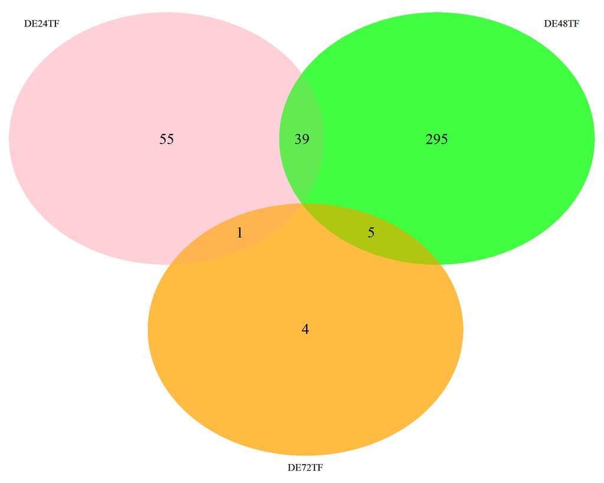

```r
library(VennDiagram)
c <- calculate.overlap(x = list("DE24TF"=DE24TF,
                                      "DE48TF"=DE48TF,
                                      "DE72TF"=DE72TF))
venn.plot <-draw.triple.venn(
  area1 = length(DE24TF),
  area2 = length(DE48TF),
  area3 = length(DE72TF),
  n12 = length(c[[2]])+length(c[[1]]),
  n23 = length(c[[4]])+length(c[[1]]),
  n13 = length(c[[3]])+length(c[[1]]),
  n123 = length(c[[1]]),
  fill = c("pink", "green", "orange"),
  category = c("DE24TF", "DE48TF","DE72TF"),
  lty = "blank", cex = 1.5)
grid.draw(venn.plot, recording=FALSE)
```

## Mark genes that TF in topTable

```r
#Mark TF genes in topTable
# topTables_stable_TF <- topTables_stable[1:3] %>%
#   sapply(function(x){
#     x %>% as.data.frame() %>%
#       mutate(TF = case_when(gene_name %in% mmTF & DE == TRUE ~ TRUE),
#       TF = ifelse(is.na(TF), "FALSE", TF))}, simplify = FALSE)

topTables_stable_TF <- readRDS("C:/Users/cronos/Box Sync/Desktop/Renal Hypertrophy/CRH_RNAseq/topTables_stable_TF.rds")
```

List transcription factors that are DE and stable in Sham

```r
topTables_stable_TF[[1]] %>%
  dplyr::filter(DE==TRUE, Stable==TRUE, TF==TRUE ) %>%
    dplyr::select(-chromosome, -start, -end, -description, -gc_content, -length) %>%
    kable %>%
  kable_styling() %>%
  scroll_box(height="300px")
```

| No. | gene_id | gene_name | gene_biotype | entrezid | logFC | AveExpr | t | P.Value | adj.P.Val | DE | Status | Stable | TF |
| --- | --- | --- | --- | --- | --- | --- | --- | --- | --- | --- | --- | --- | --- |
| 424 | ENSMUSG00000017801 | Mlx | protein_coding | 21428 | 0.3867386 | 5.2325933 | 4.396051 | 0.0000496 | 0.0015400 | TRUE | Up | TRUE | TRUE |
| 433 | ENSMUSG00000002996 | Hbp1 | protein_coding | 73389 | -0.5251159 | 6.1007389 | -4.357185 | 0.0000557 | 0.0016885 | TRUE | Down | TRUE | TRUE |
| 543 | ENSMUSG00000034522 | Zfp395 | protein_coding | 380912 | -0.8292639 | 3.9796709 | -4.036387 | 0.0001432 | 0.0034682 | TRUE | Down | TRUE | TRUE |
| 583 | ENSMUSG00000039275 | Foxk2 | protein_coding | 68837 | 0.3971588 | 5.0519105 | 3.942964 | 0.0001859 | 0.0041964 | TRUE | Up | TRUE | TRUE |
| 691 | ENSMUSG00000000823 | Zfp512b | protein_coding | 269401 | -0.3641864 | 4.8876217 | -3.695714 | 0.0003758 | 0.0071566 | TRUE | Down | TRUE | TRUE |
| 697 | ENSMUSG00000072294 | Klf12 | protein_coding | 16597 | -0.5683838 | 4.0754961 | -3.676212 | 0.0003974 | 0.0075024 | TRUE | Down | TRUE | TRUE |
| 738 | ENSMUSG00000016477 | E2f3 | protein_coding | 13557 | 0.5680120 | 2.9504983 | 3.612031 | 0.0004758 | 0.0084838 | TRUE | Up | TRUE | TRUE |
| 826 | ENSMUSG00000020644 | Id2 | protein_coding | 15902 | 0.4473064 | 7.2988678 | 3.443136 | 0.0007593 | 0.0120951 | TRUE | Up | TRUE | TRUE |
| 863 | ENSMUSG00000039191 | Rbpj | protein_coding | 19664 | -0.3026386 | 5.1674223 | -3.371151 | 0.0009245 | 0.0140943 | TRUE | Down | TRUE | TRUE |
| 938 | ENSMUSG00000078899 | Gm4631 | protein_coding | 10263315…. | 0.4020186 | 4.4524053 | 3.261187 | 0.0012454 | 0.0174706 | TRUE | Up | TRUE | TRUE |
| 1028 | ENSMUSG00000035443 | Thyn1 | protein_coding | 77862 | 0.3518375 | 3.4039888 | 3.120897 | 0.0018106 | 0.0231611 | TRUE | Up | TRUE | TRUE |
| 1050 | ENSMUSG00000041272 | Tox | protein_coding | 252838 | -0.8858578 | 0.0983976 | -3.111879 | 0.0019292 | 0.0241762 | TRUE | Down | TRUE | TRUE |
| 1077 | ENSMUSG00000023990 | Tfeb | protein_coding | 21425 | 0.3731898 | 3.8968451 | 3.060866 | 0.0021205 | 0.0258753 | TRUE | Up | TRUE | TRUE |
| 1084 | ENSMUSG00000046897 | Zfp740 | protein_coding | 68744 | -0.3160457 | 5.4508746 | -3.057965 | 0.0021366 | 0.0259353 | TRUE | Down | TRUE | TRUE |
| 1108 | ENSMUSG00000031393 | Mecp2 | protein_coding | 17257 | -0.2887132 | 5.2368420 | -3.036316 | 0.0022611 | 0.0268519 | TRUE | Down | TRUE | TRUE |
| 1109 | ENSMUSG00000094786 | Gm14403 | protein_coding | NA | 0.7231824 | 1.8144386 | 3.042202 | 0.0022664 | 0.0268903 | TRUE | Up | TRUE | TRUE |
| 1119 | ENSMUSG00000068959 | Zfp619 | protein_coding | 70227 | 0.6909477 | 1.1029584 | 3.022641 | 0.0023772 | 0.0279526 | TRUE | Up | TRUE | TRUE |
| 1125 | ENSMUSG00000043099 | Hic1 | protein_coding | 15248 | 0.7508345 | 1.3562864 | 3.020333 | 0.0024103 | 0.0281905 | TRUE | Up | TRUE | TRUE |
| 1148 | ENSMUSG00000029553 | Tfec | protein_coding | 21426 | 0.5865102 | 3.5916844 | 2.991540 | 0.0025546 | 0.0292796 | TRUE | Up | TRUE | TRUE |
| 1168 | ENSMUSG00000037001 | Zfp39 | protein_coding | 22698 | -0.4771861 | 2.8830132 | -2.968313 | 0.0027009 | 0.0304267 | TRUE | Down | TRUE | TRUE |
| 1178 | ENSMUSG00000090963 | Gm17655 | protein_coding | NA | 0.8158684 | -0.0791609 | 2.967855 | 0.0027975 | 0.0312472 | TRUE | Up | TRUE | TRUE |
| 1183 | ENSMUSG00000066880 | Zfp617 | protein_coding | 170938 | 0.3440914 | 4.2279662 | 2.946223 | 0.0028566 | 0.0317727 | TRUE | Up | TRUE | TRUE |
| 1231 | ENSMUSG00000026987 | Baz2b | protein_coding | 407823 | -0.5821353 | 5.0515557 | -2.897686 | 0.0032564 | 0.0348074 | TRUE | Down | TRUE | TRUE |
| 1274 | ENSMUSG00000074519 | Zfp971 | protein_coding | 626848 | 0.4995782 | 2.5919814 | 2.861659 | 0.0035545 | 0.0367108 | TRUE | Up | TRUE | TRUE |
| 1392 | ENSMUSG00000032998 | Foxj3 | protein_coding | 230700 | -0.3100810 | 5.0863832 | -2.737447 | 0.0048492 | 0.0458371 | TRUE | Down | TRUE | TRUE |

```r
topTables_stable_TF[[2]] %>%
  dplyr::filter(DE==TRUE, Stable==TRUE, TF==TRUE ) %>%
    dplyr::select(-chromosome, -start, -end, -description, -gc_content, -length) %>%
    kable %>%
  kable_styling() %>%
  scroll_box(height="300px")
```

| No. | gene_id | gene_name | gene_biotype | entrezid | logFC | AveExpr | t | P.Value | adj.P.Val | DE | Status | Stable | TF |
| --- | --- | --- | --- | --- | --- | --- | --- | --- | --- | --- | --- | --- | --- |
| 346 | ENSMUSG00000046711 | Hmga1 | protein_coding | 15361 | 0.8962809 | 4.4630701 | 6.862054 | 0.0000000 | 0.0000011 | TRUE | Up | TRUE | TRUE |
| 404 | ENSMUSG00000038766 | Gabpb2 | protein_coding | 213054 | -0.5305762 | 5.0675656 | -6.639441 | 0.0000001 | 0.0000019 | TRUE | Down | TRUE | TRUE |
| 411 | ENSMUSG00000046897 | Zfp740 | protein_coding | 68744 | -0.5737285 | 5.4508746 | -6.600368 | 0.0000001 | 0.0000021 | TRUE | Down | TRUE | TRUE |
| 413 | ENSMUSG00000060601 | Nr1h2 | protein_coding | 22260 | 0.5102088 | 5.5633654 | 6.589911 | 0.0000001 | 0.0000022 | TRUE | Up | TRUE | TRUE |
| 461 | ENSMUSG00000047036 | Zfp445 | protein_coding | 235682 | -0.6518870 | 5.8706840 | -6.345199 | 0.0000001 | 0.0000040 | TRUE | Down | TRUE | TRUE |
| 566 | ENSMUSG00000094483 | Purb | protein_coding | 19291 | -0.4250979 | 6.1460424 | -5.912523 | 0.0000005 | 0.0000121 | TRUE | Down | TRUE | TRUE |
| 573 | ENSMUSG00000039789 | Zfp597 | protein_coding | 71063 | -0.8609014 | 2.8771466 | -5.877773 | 0.0000006 | 0.0000133 | TRUE | Down | TRUE | TRUE |
| 575 | ENSMUSG00000032652 | Crebl2 | protein_coding | 232430 | -0.5351596 | 5.1714418 | -5.874474 | 0.0000006 | 0.0000133 | TRUE | Down | TRUE | TRUE |
| 580 | ENSMUSG00000012640 | Zfp715 | protein_coding | 69930 | -0.6849659 | 3.6075501 | -5.862614 | 0.0000006 | 0.0000137 | TRUE | Down | TRUE | TRUE |
| 590 | ENSMUSG00000030386 | Zfp606 | protein_coding | 67370 | -0.6722328 | 3.0546977 | -5.828730 | 0.0000007 | 0.0000149 | TRUE | Down | TRUE | TRUE |
| 610 | ENSMUSG00000053390 | Zfp952 | protein_coding | 240067 | -0.6961642 | 2.7556066 | -5.756568 | 0.0000008 | 0.0000179 | TRUE | Down | TRUE | TRUE |
| 626 | ENSMUSG00000033964 | Zbtb41 | protein_coding | 226470 | -0.5157695 | 5.5649505 | -5.716824 | 0.0000009 | 0.0000197 | TRUE | Down | TRUE | TRUE |
| 670 | ENSMUSG00000089756 | Zfp966 | protein_coding | 667962 | -1.1194126 | 2.3279775 | -5.614378 | 0.0000013 | 0.0000253 | TRUE | Down | TRUE | TRUE |
| 673 | ENSMUSG00000044876 | Zfp444 | protein_coding | 72667 | 0.5778086 | 4.8597013 | 5.607844 | 0.0000013 | 0.0000255 | TRUE | Up | TRUE | TRUE |
| 674 | ENSMUSG00000074165 | Zfp788 | protein_coding | 67607 | -0.8510874 | 2.6772899 | -5.603446 | 0.0000013 | 0.0000258 | TRUE | Down | TRUE | TRUE |
| 718 | ENSMUSG00000062761 | Zfp512 | protein_coding | 269639 | -0.5159480 | 3.5851379 | -5.447429 | 0.0000021 | 0.0000388 | TRUE | Down | TRUE | TRUE |
| 803 | ENSMUSG00000056216 | Cebpg | protein_coding | 12611 | -0.5027515 | 5.0077536 | -5.209046 | 0.0000044 | 0.0000714 | TRUE | Down | TRUE | TRUE |
| 825 | ENSMUSG00000067942 | Zfp160 | protein_coding | 224585 | -0.6483530 | 2.9967011 | -5.148829 | 0.0000052 | 0.0000834 | TRUE | Down | TRUE | TRUE |
| 874 | ENSMUSG00000096433 | Zfp994 | protein_coding | 240038 | -0.6907266 | 3.1302793 | -5.041223 | 0.0000072 | 0.0001089 | TRUE | Down | TRUE | TRUE |
| 892 | ENSMUSG00000039219 | Arid4b | protein_coding | 94246 | -0.5425424 | 4.6403109 | -4.990180 | 0.0000084 | 0.0001243 | TRUE | Down | TRUE | TRUE |
| 898 | ENSMUSG00000070709 | Zfp974 | protein_coding | 73430 | -0.8067651 | 2.3243399 | -4.984348 | 0.0000086 | 0.0001259 | TRUE | Down | TRUE | TRUE |
| 948 | ENSMUSG00000078894 | 2210418O10Rik | protein_coding | 100504263 | -0.5716379 | 3.5549675 | -4.869149 | 0.0000121 | 0.0001683 | TRUE | Down | TRUE | TRUE |
| 966 | ENSMUSG00000063894 | Zkscan8 | protein_coding | 93681 | -0.5883035 | 4.2779898 | -4.848384 | 0.0000129 | 0.0001758 | TRUE | Down | TRUE | TRUE |
| 1015 | ENSMUSG00000051341 | Zfp52 | protein_coding | 22710 | -0.9872935 | 1.9458512 | -4.739526 | 0.0000181 | 0.0002340 | TRUE | Down | TRUE | TRUE |
| 1020 | ENSMUSG00000054648 | Zfp869 | protein_coding | 66869 | -0.4279601 | 4.2619625 | -4.719542 | 0.0000190 | 0.0002448 | TRUE | Down | TRUE | TRUE |
| 1100 | ENSMUSG00000059142 | Zfp945 | protein_coding | 240041 | -0.6554346 | 3.3629555 | -4.575818 | 0.0000292 | 0.0003487 | TRUE | Down | TRUE | TRUE |
| 1114 | ENSMUSG00000079215 | Zfp664 | protein_coding | 269704 | -0.3625198 | 6.0066139 | -4.557075 | 0.0000308 | 0.0003633 | TRUE | Down | TRUE | TRUE |
| 1146 | ENSMUSG00000059552 | Trp53 | protein_coding | 22059 | 0.4840694 | 4.3731095 | 4.507449 | 0.0000357 | 0.0004098 | TRUE | Up | TRUE | TRUE |
| 1166 | ENSMUSG00000021775 | Nr1d2 | protein_coding | 353187 | -0.8265031 | 6.4139318 | -4.487506 | 0.0000380 | 0.0004292 | TRUE | Down | TRUE | TRUE |
| 1181 | ENSMUSG00000090015 | Gm15446 | protein_coding | 100642166 | -0.8179129 | 2.1615533 | -4.474086 | 0.0000396 | 0.0004409 | TRUE | Down | TRUE | TRUE |

[output cut: 152 more lines]

```r
topTables_stable_TF[[3]] %>%
  dplyr::filter(DE==TRUE, Stable==TRUE, TF==TRUE ) %>%
    dplyr::select(-chromosome, -start, -end, -description, -gc_content, -length) %>%
    kable %>%
  kable_styling() %>%
  scroll_box(height="300px")
```

| No. | gene_id | gene_name | gene_biotype | entrezid | logFC | AveExpr | t | P.Value | adj.P.Val | DE | Status | Stable | TF |
| --- | --- | --- | --- | --- | --- | --- | --- | --- | --- | --- | --- | --- | --- |
| 6 | ENSMUSG00000059824 | Dbp | protein_coding | 13170 | -2.1047708 | 5.226628 | -5.995235 | 0.0000004 | 0.0009586 | TRUE | Down | TRUE | TRUE |
| 21 | ENSMUSG00000021775 | Nr1d2 | protein_coding | 353187 | -0.8626765 | 6.413932 | -5.439480 | 0.0000022 | 0.0013632 | TRUE | Down | TRUE | TRUE |
| 38 | ENSMUSG00000055116 | Arntl | protein_coding | 11865 | 1.5688472 | 2.876708 | 4.860872 | 0.0000132 | 0.0044701 | TRUE | Up | TRUE | TRUE |
| 108 | ENSMUSG00000029238 | Clock | protein_coding | 12753 | 0.3987791 | 5.914958 | 3.810280 | 0.0002717 | 0.0331054 | TRUE | Up | TRUE | TRUE |

Overlap DE TF that are stable in Sham

```r
stable_TF_24 <-topTables_stable_TF[[1]] %>%
  dplyr::filter(DE==TRUE, Stable==TRUE, TF==TRUE ) %>%
  .$gene_id

stable_TF_48 <-topTables_stable_TF[[2]] %>%
  dplyr::filter(DE==TRUE, Stable==TRUE, TF==TRUE ) %>%
  .$gene_id

stable_TF_72 <-topTables_stable_TF[[3]] %>%
  dplyr::filter(DE==TRUE, Stable==TRUE, TF==TRUE ) %>%
  .$gene_id
```

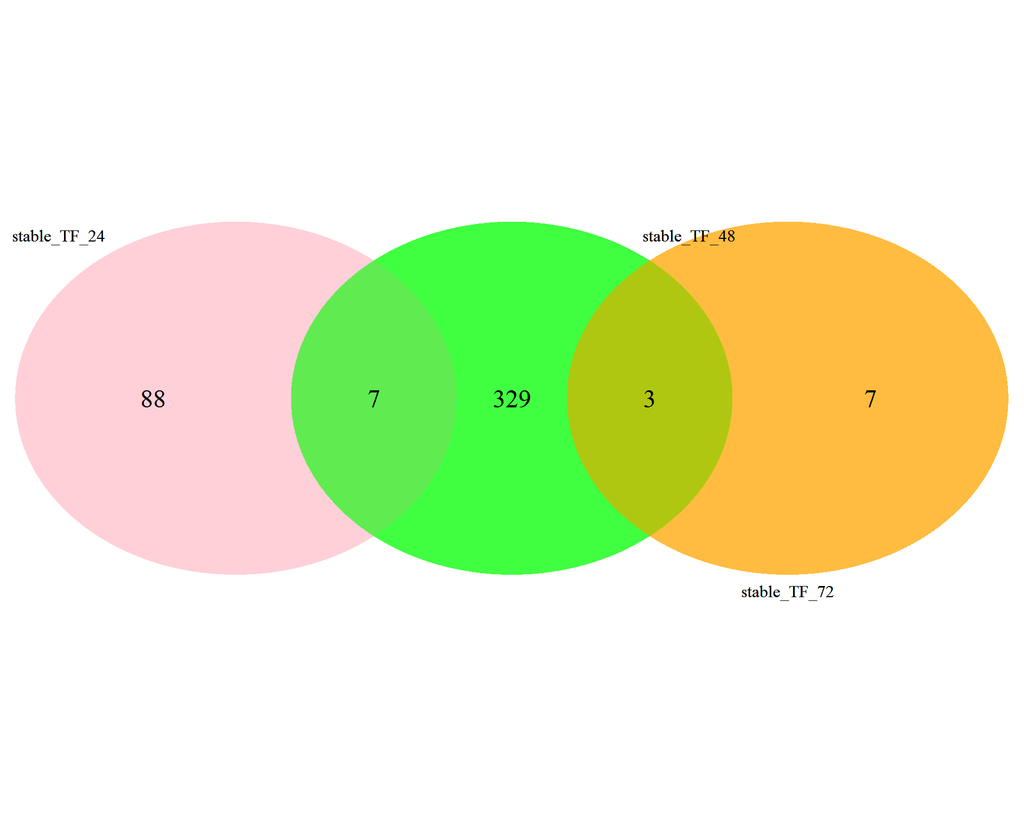

```r
c <- calculate.overlap(x = list("stable_TF_24"=stable_TF_24,
                                      "stable_TF_48"=stable_TF_48,
                                      "stable_TF_72"=stable_TF_72))
venn.plot <-draw.triple.venn(
  area1 = length(DE24TF),
  area2 = length(DE48TF),
  area3 = length(DE72TF),
  n12 = length(c[[2]])+length(c[[1]]),
  n23 = length(c[[4]])+length(c[[1]]),
  n13 = length(c[[3]])+length(c[[1]]),
  n123 = length(c[[1]]),
  fill = c("pink", "green", "orange"),
  category = c("stable_TF_24", "stable_TF_48","stable_TF_72"),
  lty = "blank", cex = 1.5)
grid.draw(venn.plot, recording=FALSE)
```

Extract overlapped TF

```r
extract_TF <- c(c[["a2"]],c[["a6"]])
```

Plot expression of overlapped TF

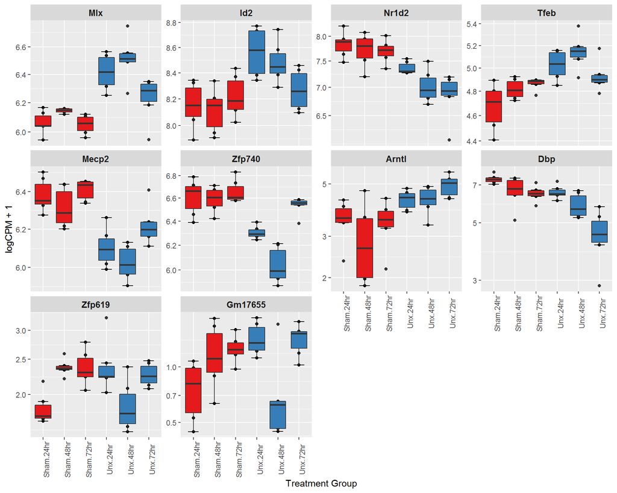

```r
cpm(dgeList, log=TRUE, prior.count = 3)[extract_TF,] %>%
  as.data.frame() %>%
  rownames_to_column("gene_id") %>%
    as_tibble() %>%
    gather(key = "sample", value = "CPM", -gene_id) %>%
    mutate(CPM = CPM + 1) %>%
    left_join(dgeList$samples) %>%
  mutate(treatment = fct_relevel(treatment, "Sham","Unx")) %>%
  mutate(group = fct_relevel(group, "Sham.24hr","Sham.48hr","Sham.72hr","Unx.24hr","Unx.48hr","Unx.72hr")) %>%
    ggplot(aes(group, CPM, fill = treatment)) +
  geom_point() +
    # geom_text_repel(aes(label = time)) +
  stat_boxplot(geom='errorbar', linetype=1, width=0.5)+
    geom_boxplot() +
    facet_wrap(
        ~gene_id,
        scales = "free_y",
        labeller = as_labeller(
            structure(dgeList$genes$gene_name, names = dgeList$genes$gene_id)
        )) + scale_fill_manual(values = treatCols) +
    scale_y_log10()  +
    labs(x = "Treatment Group",
         y = "logCPM + 1") +
    theme(legend.position = "none",axis.text.x = element_text(angle = 90),
          strip.text = element_text(size= 10, face="bold"))
```

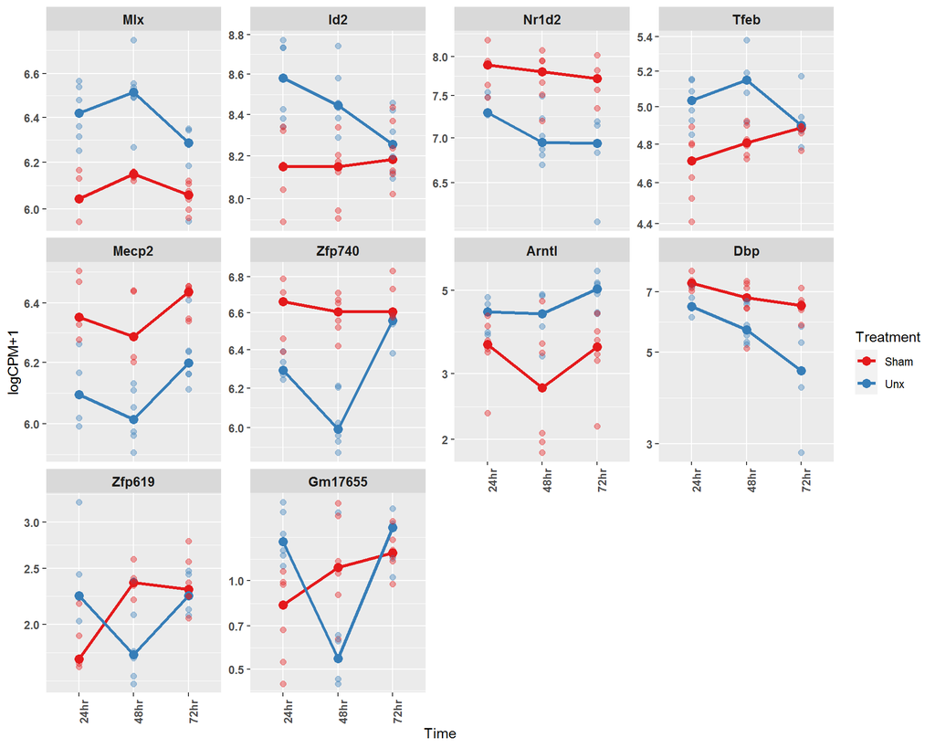

```r
#Create median expression of dataframe

cpm<- cpm(dgeList, log=TRUE, prior.count = 3)[extract_TF,] %>%
  as.data.frame() %>%
  rownames_to_column("gene_id") %>%
    as_tibble() %>%
    gather(key = "sample", value = "CPM", -gene_id) %>%
    mutate(CPM = CPM + 1) %>%
    left_join(dgeList$samples) %>%
  mutate(treatment = fct_relevel(treatment, "Sham","Unx")) %>%
  mutate(group = fct_relevel(group, "Sham.24hr","Sham.48hr","Sham.72hr","Unx.24hr","Unx.48hr","Unx.72hr"))

median <- aggregate(cpm$CPM,
            by=list(cpm$treatment,
                    cpm$time,
                    cpm$gene_id),
                 function(x)median(x, na.rm=TRUE)) %>%
  set_colnames( c("treatment", "time","gene_id","CPM"))

#plot
ggplot(median,
       aes(x= time, y=CPM, group=treatment)) +
  geom_line(aes(colour=treatment),size =1.2) +
  geom_point(aes(colour=treatment),size = 3) +
  geom_point(data=cpm, aes(colour=treatment)
             ,size = 2, alpha = 0.4)+
  facet_wrap(
    ~gene_id,
    scales = "free_y",
    labeller = as_labeller(
            structure(dgeList$genes$gene_name, names = dgeList$genes$gene_id)))+
  scale_colour_manual(values = treatCols) +
  scale_y_log10()  +
  labs(x = "Time",
       y = "logCPM+1",
       colour = "Treatment") +
  theme(axis.text.x = element_text(angle = 90, face= "bold"),
        axis.text.y = element_text(face= "bold"),
        strip.text = element_text(size= 10, face="bold"))
```

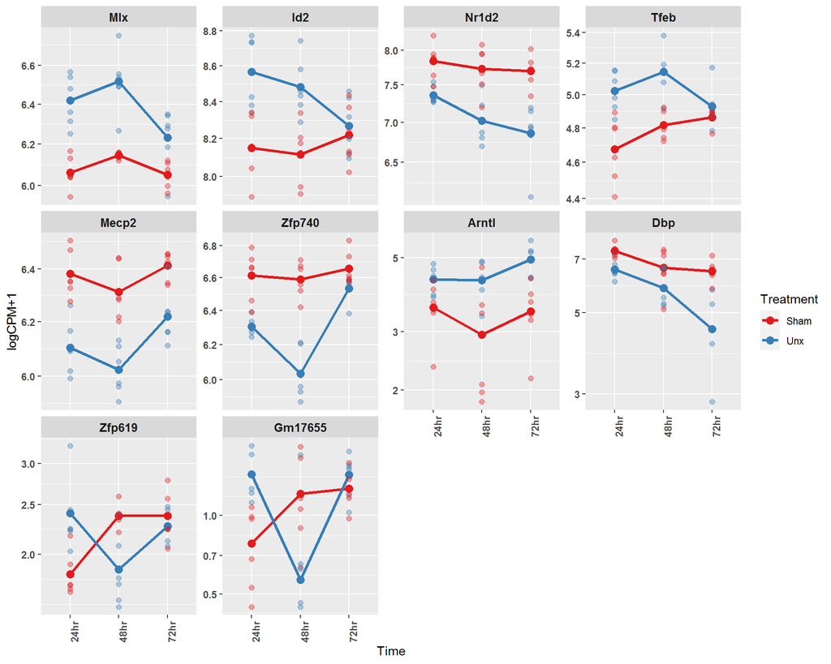

```r
#Create median expression of dataframe

cpm<- cpm(dgeList, log=TRUE, prior.count = 3)[extract_TF,] %>%
  as.data.frame() %>%
  rownames_to_column("gene_id") %>%
    as_tibble() %>%
    gather(key = "sample", value = "CPM", -gene_id) %>%
    mutate(CPM = CPM + 1) %>%
    left_join(dgeList$samples) %>%
  mutate(treatment = fct_relevel(treatment, "Sham","Unx")) %>%
  mutate(group = fct_relevel(group, "Sham.24hr","Sham.48hr","Sham.72hr","Unx.24hr","Unx.48hr","Unx.72hr"))

mean <- aggregate(cpm$CPM,
            by=list(cpm$treatment,
                    cpm$time,
                    cpm$gene_id),
                 function(x)mean(x, na.rm=TRUE)) %>%
  set_colnames( c("treatment", "time","gene_id","CPM"))

#plot
ggplot(mean,
       aes(x= time, y=CPM, group=treatment)) +
  geom_line(aes(colour=treatment),size =1.2) +
  geom_point(aes(colour=treatment),size = 3) +
  geom_point(data=cpm, aes(colour=treatment)
             ,size = 2, alpha = 0.4)+
  facet_wrap(
    ~gene_id,
    scales = "free_y",
    labeller = as_labeller(
            structure(dgeList$genes$gene_name, names = dgeList$genes$gene_id)))+
  scale_colour_manual(values = treatCols) +
  scale_y_log10()  +
  labs(x = "Time",
       y = "logCPM+1",
       colour = "Treatment") +
  theme(axis.text.x = element_text(angle = 90, face= "bold"),
        axis.text.y = element_text(face= "bold"),
        strip.text = element_text(size= 10, face="bold"))
```

## Look for transcription factors cofactors

```r
Mus_musculus_TF_cofactors <- read.delim("C:/Users/cronos/Box Sync/Desktop/Renal Hypertrophy/CRH_RNAseq/Mus_musculus_TF_cofactors.txt")
```

## Enrichment analysis of DE genes are specific to Unx from each timepoint

### GO Enrichment Analysis

```r
minPath <- 4
goSummaries <- url("https://uofabioinformaticshub.github.io/summaries2GO/data/goSummaries.RDS") %>%
    readRDS() %>%
    dplyr::rename(go_id = id)
```

A very brief enrichment analysis was then performed using the default settings of the function `goana()`. As `goana` relies on entrezgene identifiers, analysis was switched to these IDs for this step of the analysis. Results were then limited to GO terms with at least 4 steps back the root terms for each ontology.

```r
orgDb <- org.Mm.eg.db
sigIDs <- topTables_stable$Sham48vsUnx48 %>%
    dplyr::filter(adj.P.Val < 0.05 & Status=="Up" & Stable==TRUE) %>%
    extract2("entrezid") %>%
    unlist() %>%
  na.omit() %>%
    unique()
uv <- unlist(topTables_stable$Sham48vsUnx48$entrezid) %>%
  na.omit() %>%
  unique()
```

```r
goRes <- goana.default(sigIDs, universe = uv, species = "Mm") %>%
    rownames_to_column("go_id") %>%
    dplyr::rename(ontology = Ont) %>%
    as_tibble() %>%
    dplyr::filter(DE > 0) %>%
    left_join(goSummaries)
```

A total of 8,569 GO terms were identified amongst the differentially expressed genes.

```r
goRes %>%
    dplyr::filter(shortest_path > minPath) %>%
    mutate(adjP = p.adjust(P.DE, "bonferroni"),
           FDR = p.adjust(P.DE, "fdr")) %>%
    arrange(ontology, P.DE) %>%
    dplyr::filter(FDR < 0.05) %>%
    mutate(Expected_DE = round(length(sigIDs) * N / length(uv), 1)) %>%
    dplyr::select(`GO ID` = go_id, Term, Ontology = ontology, N, Obs_DE = DE, Expected_DE, P.DE, FDR) %>%
    pander(caption = "*Significantly enriched GO terms using a FDR-adjusted p-value < 0.05 as the criteria for significance*",
           split.tables = Inf)
```

*Significantly enriched GO terms using a FDR-adjusted p-value < 0.05 as the criteria for significance*

| GO ID | Term | Ontology | N | Obs_DE | Expected_DE | P.DE | FDR |
| --- | --- | --- | --- | --- | --- | --- | --- |
| GO:0005743 | mitochondrial inner membrane | CC | 416 | 52 | 26.2 | 1.598e-06 | 0.006543 |

#### GO Visualisations

```r
go2Drop <- dplyr::filter(goSummaries, shortest_path <= minPath)$go_id
```

In order to visualise the results of the GO analysis, the R package `clusterProfiler` was used. The same strategy was used for removal of high-level GO terms, which resulted in the omission of 18,545 high-level (i.e. less informative) GO terms from the analysis.

```r
    eGO <- c("BP", "CC", "MF") %>%
        sapply(function(x){
            enrichGO(
                gene = as.character(sigIDs),
                # universe = as.character(uv),
                ont = x,
                pAdjustMethod = "none",
                pvalueCutoff = 0.05 ,
                minGSSize = 5,
                OrgDb = orgDb,
                readable = TRUE
            ) %>%
                dropGO(.,term = go2Drop)
        }, simplify = FALSE)
```

```r
# fc <- structure(
#   dplyr::filter(topTables_stable$Sham48vsUnx48, DE)$logFC,
#   names = dplyr::filter(topTables_stable$Sham48vsUnx48, DE)$entrezid)
#

fc <- structure(
    dplyr::filter(topTables_stable$Sham48vsUnx48 %>%
                    separate_rows(entrezid, sep ="/"), DE)$logFC,
    names = dplyr::filter(topTables_stable$Sham48vsUnx48 %>%
                    separate_rows(entrezid, sep ="/"), DE)$entrezid)
```

##### **Biological Process**

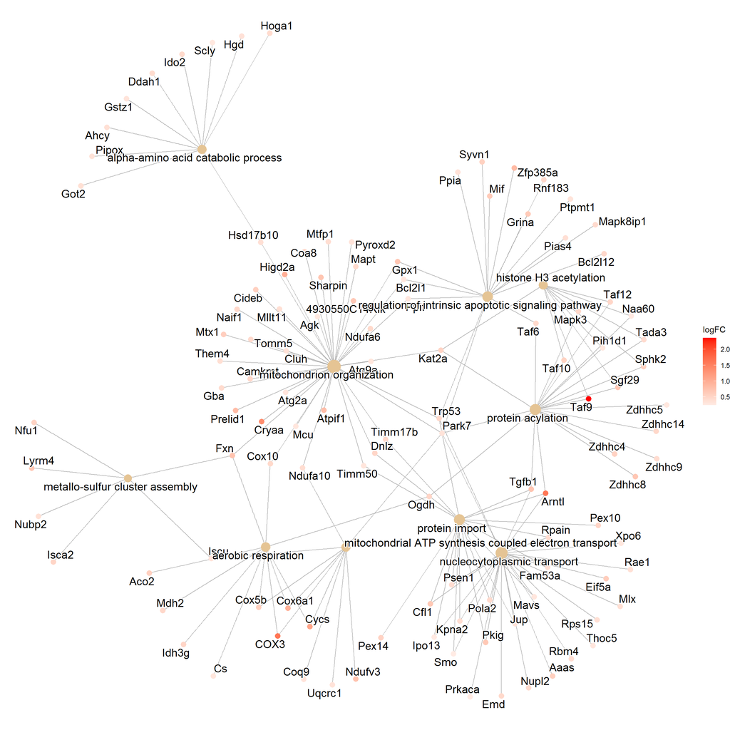

*Enrichment plot showing GO terms and related genes from the Biological Process Ontology.*